# Red Background Increases Men’s Perceived Attractiveness

*N* removed NAs: 2

*N* removed <18: 14

*N* total clean: 133

| Group | *N* | *M*<sub>age</sub> | *M*<sub>rating</sub> |
| --- | --- | --- | --- |
| Control | 65 | 21.0 | 6.56 |
| Experim | 68 | 20.9 | 7.50 |

**Main analysis results**

*t*(131) = -7.22, *p* < .001

# Red Background Increases Men’s Perceived Attractiveness

A Replication of Elliot et al. (2010) Red Study

# Methods

## Participants

Table 1 *Descriptive Statistics of Condition and Years*

| Condition | *N* | % | *M*<sub>years</sub> | *SD*<sub>years</sub> |
| --- | --- | --- | --- | --- |
| White | 65 | 48.9 | 21.0 | 2.36 |
| Red | 68 | 51.1 | 20.9 | 2.16 |

## Design

The present study examined whether the colour red can influence attractiveness. A between-subject study was employed with colour being the independent categorical variable and attractiveness being the dependent continuous variable.

Participants were randomly assigned to either a red (Experimental) or white (Control) condition. They were then given a black-and-white photo of a man either on a white or red frame for 5 seconds (see Figures 1 and 2). Using Elliot et al. (2010) measure, participants continued to report their perception of the male’s attractiveness. This was operationalised through three face-valid questions:

1. “How attractive do you think this person is?”
2. “How pleasant is this person to look at?”
3. “If I were to meet the person in this picture face to face, I would think he is attractive.”

All the items were measured on a Likert scale with a rating from 1 (“Not at all”) to 9 (“Yes, definitely”). The conceptual hypothesis is therefore operationalised into whether seeing a different colour frame around an image of a moderately attractive man influence the mean ratings of his attractiveness. An independent-samples *t*-test was then administered to test this hypothesis.

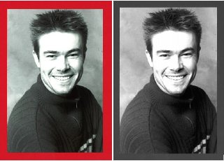

*Figures 1 and 2.* Pictures used in the colour manipulation. Left: Red frame. Right: White frame.

# Results

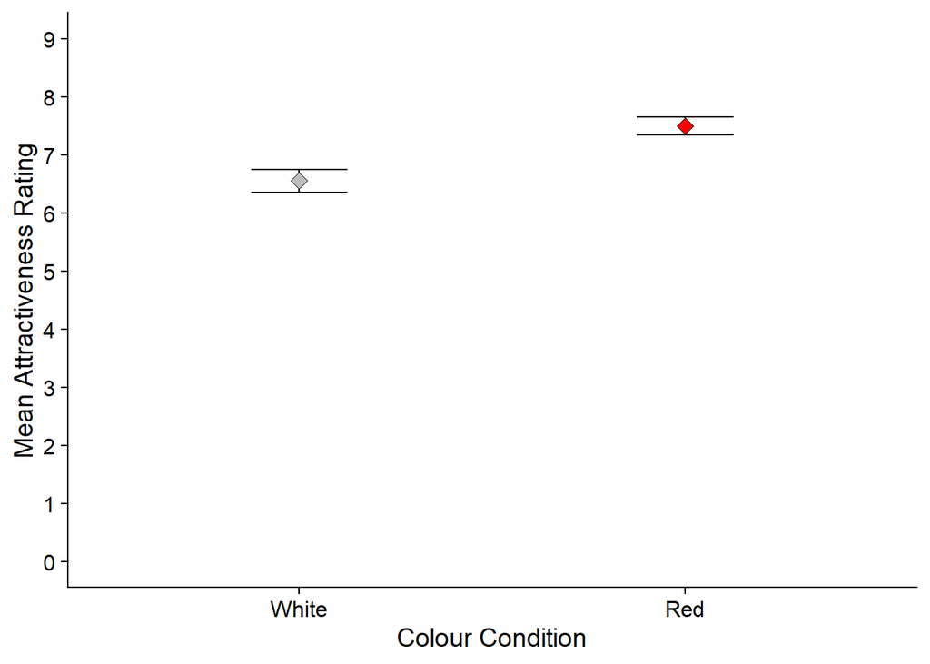

# Discussion

The author replicated the basic paradigm used in Elliot et al. (2010) red study (Experiment 1), in which the current data suggested that the same experimental condition that affected females’ perception of attractiveness still operates the same way today. Results supported the hypothesis that the colour red positively influenced heterosexual females’ ratings of attractiveness. The effect was shown among 133 individuals where those in the experimental (red) group indicated significantly higher mean attractiveness than those in the control (white) group. These findings thus indicate that colour manipulation of the background can promote female’s perceived attractiveness of a male.

The present results have practical and conceptual implications, as it extends the multiple works of studies that showed the production of the red effect under similar conditions (Elliot et al, 2010). Current findings converge with other lines of work indicating that manipulating red can increase attraction to men (Pazda & Elliot, 2016). We can thereby confirm that the colour red, including reading the word ’red’and seeing red clothes and background (see Pazda & Elliot, 2016; Elliot et al, 2010), differ from one another only in form, but not in the nature of its effect. This suggests that red plays a major role in human psychological functioning, especially in terms of romance. The fact that red carries subjective meanings and signal functions help increase men’s perceived attractiveness in a social context (Wu, Lu, Dijk, Li & Schnall, 2018; Thorstenson, Pazda, Elliot & Perrett, 2016). This, therefore, could be of interest to those involved in the realm of romance-relevant industry (e.g. marketers, fashion designers etc., Elliot, Tracy, Pazda & Beall, 2012).

On the other hand, data from multiple studies failed to support the red effect. When used in comparison with other colours, a different pattern of results emerged. Peperkoorn, Roberts, and Pollet. (2016) discovered no significant difference between attractiveness ratings when three colours were used (i.e. red, white, and black shirt). Additionally, Hesslinger, Goldbach, and Carbon. (2015) questioned the original study’s ecological validity when they found no significant red effect on male’s perceived attractiveness, despite replicating Elliot et al. (2010) experiment 1 and having a larger sample size (*n* = 72 vs Elliot et al *n* = 21). Although the author notes that replication studies will never be exact (Brandt et al, 2014), these studies have led us to question the robustness of the red effect as proposed by Elliot et al. (2010) and its subsequent replications (Peperkoorn et al., 2016; Hesslinger et al., 2015). As Peperkoorn et al. (2016) pointed out, “Conducting research on the psychological effects of color requires understanding of the complexities involved in generating appropriate stimulus materials” (p.10). Therefore, acknowledging the study’s implications (i.e. the replications’ null and alternative findings) will help future research in better understanding the influence of colour on attractiveness (Peperkoorn et al., 2016; Seguin & Forstmeier, 2012).

The current research has some limitations that can be considered for future research. First, the current research focuses on a narrow age group, young adults aged 18 to 27 (Institute of Medicine and National Research Council, 2015). Although we can demonstrate that the color findings observed with young adults may also be found with younger participants, we cannot extend our findings onto older individuals (Buechner, Maier, Lichtenfeld & Elliot, 2014). Elliot and Niesta. (2008) proposed that the effect of red is stronger on sexually explicit measures than physical attractiveness. This thus questions red effects’ external validity on older females, especially in menopausal women (Schwarz & Singer, 2012). Therefore, the next step should be to replicate the present work while simultaneously extending it to older females. Besides, such studies could test additional hypotheses such as whether the red effect is a cue for ovulation or menopause. This is supported by previous studies demonstrating that women preferred more provocative clothes prior to ovulation (Durante, Griskevicius, Hill, Perilloux & Li, 2011; Haselton, Mortezaie, Pillsworth & Bleske-Rechek, 2007).

Second, the present study used only self-reports from the female participants. As other research has shown that the red effect affects behavioural measures (Niesta-Kayser, Elliot & Feltman, 2010), we know that it is not a methodological artifact (Schwarz & Singer, 2012). As such, using one main response format (i.e. Likert scale) suggests that some of the covariations observed among the constructs might be due to the scale’s consistency rather than its content (Podsakoff, MacKenzie, Lee & Podsakoff, 2003). Therefore, further studies may want to use a combination of objective measurements (e.g. using response time as seen in the study by Wu et al., 2018) and self-reports to try to acquire a more accurate data of the red effect.

Third, our results reflect a singular finding obtained through one laboratory experiment. Therefore, we are unable to comment on its ecological validity when there might be other factors impacting attractiveness besides the target’s background colour. In this regard, using a static stimuli means that we are limited by the unmeasurable difference between the processes that happen in a strictly-controlled experiment and those taking place in the more complicated real-life setting (Hesslinger et al., 2015). As such, future research is needed to test the red effect’s influence on both a static and dynamic stimuli (e.g. facial redness) in a more naturalistic setting. Since Tan and Stephen. (2013) demonstrated that human is capable at detecting facial colouration changes, we are better able to generalise the red effect to different stimuli (see Thorstenson et al., 2016; Abbeele, Penton-Voak, Attwood, Stephen & Munafò, 2015). Additionally, we propose that self-attractiveness of the target might further influence his perceived attractiveness (e.g. wearing formal wear vs t-shirt on a date; Hesslinger et al., 2015).

In conclusion, our data support the red effect as reported by Elliot et al. (2010) experiment 1; that is red can enhance a male’s perceived attractiveness when his picture is seen through a red frame. We see that participants in the red group indicated significantly higher mean attractiveness than those in the white group. This suggested that the red frame may have increased the male’s perceived attractiveness. Future studies should seek to replicate this finding by using a combination of measures and determine whether the red effect can be generalised to an older age range. It would also be interesting to discover whether similar results can be obtained through a naturalistic setting in the presence of other variables. Understanding the various factors through which red effect is produced, including its effects on both genders, is important for many judgement calls in business and sports industries (e.g. *luxury brands*, see Adomaitis & Saiki, 2019; Wu et al., 2018, and *athletes*, see Hill & Barton, 2005; Farrelly, Slater, Elliott, Walden & Wetherell, 2013).

**Words: 1, 484**

# References

Abbeele, J., Penton-Voak, I., Attwood, A., Stephen, I., & Munafò, M. (2015). Increased Facial Attractiveness Following Moderate, but not High, Alcohol Consumption. *Alcohol And Alcoholism, 50*(3), 296-301. doi: 10.1093/alcalc/agv010

Adomaitis, A., & Saiki, D. (2019). Brand personality and sexuality levels of

luxury advertisements. *Journal Of Fashion Marketing And Management: An International Journal, 23*(4), 572-586. doi: 10.1108/jfmm-01-2019-0004

Brandt, M., IJzerman, H., Dijksterhuis, A., Farach, F., Geller, J., & Giner-Sorolla, R. et al. (2014). The Replication Recipe: What makes for a convincing replication?. *Journal Of Experimental Social Psychology, 50*, 217-224. doi: 10.1016/j.jesp.2013.10.005

Buechner, V., Maier, M., Lichtenfeld, S., & Elliot, A. (2014). Emotion Expression and Color: Their Joint Influence on Perceived Attractiveness and Social Position. *Current Psychology, 34*(2), 422-433. doi: 10.1007/s12144-014-9266-x

Durante, K., Griskevicius, V., Hill, S., Perilloux, C., & Li, N. (2010). Ovulation, Female Competition, and Product Choice: Hormonal Influences on Consumer Behavior. *Journal Of Consumer Research, 37*(6), 921-934. doi: 10.1086/656575

Elliot, A., & Niesta, D. (2008). Romantic red: Red enhances men’s attraction to women. *Journal Of Personality And Social Psychology, 95*(5), 1150-1164. doi: 10.1037/0022-3514.95.5.1150

Elliot, A., Niesta-Kayser, D., Greitemeyer, T., Lichtenfeld, S., Gramzow, R., Maier, M., & Liu, H. (2010). Red, rank, and romance in women viewing men. *Journal Of Experimental Psychology: General, 139*(3), 399-417. doi: 10.1037/a0019689

Elliot, A., Tracy, J., Pazda, A., & Beall, A. (2013). Red enhances women’s attractiveness to men: First evidence suggesting universality. *Journal Of Experimental Social Psychology, 49*(1), 165-168. doi: 10.1016/j.jesp.2012.07.017

Farrelly, D., Slater, R., Elliott, H., Walden, H., & Wetherell, M. (2013). Competitors Who Choose to Be Red Have Higher Testosterone Levels. *Psychological Science, 24*(10), 2122-2124. doi: 10.1177/0956797613482945

Haselton, M., Mortezaie, M., Pillsworth, E., Bleske-Rechek, A., & Frederick, D. (2007). Ovulatory shifts in human female ornamentation: Near ovulation, women dress to impress. *Hormones And Behavior, 51*(1), 40-45. doi: 10.1016/j.yhbeh.2006.07.007

Hesslinger, V., Goldbach, L., & Carbon, C. (2015). Men in red: A reexamination of the red-attractiveness effect. *Psychonomic Bulletin & Review, 22*(4), 1142-1148. doi: 10.3758/s13423-015-0866-8

Hill, R., & Barton, R. (2005). Red enhances human performance in contests. *Nature, 435*(7040), 293-293. doi: 10.1038/435293a

Institute of Medicine and National Research Council. (2015). *Investing in the Health and Well-Being of Young Adults*. Washington, DC: The National Academies Press. https://doi.org/10.17226/18869.

Niesta-Kayser, D., Elliot, A., & Feltman, R. (2010). Red and romantic behavior in men viewing women. *European Journal Of Social Psychology, 40*(6), 901-908. doi: 10.1002/ejsp.757

Pazda, A., & Elliot, A. (2016). Processing the Word Red can Enhance Women’s Perceptions of Men’s Attractiveness. *Current Psychology, 36*(2), 316-323. doi: 10.1007/s12144-016-9420-8

Podsakoff, P., MacKenzie, S., Lee, J., & Podsakoff, N. (2003). Common method biases in behavioral research: A critical review of the literature and recommended remedies. *Journal Of Applied Psychology, 88*(5), 879-903. doi: 10.1037/0021-9010.88.5.879

Schwarz, S., & Singer, M. (2013). Romantic red revisited: Red enhances men’s attraction to young, but not menopausal women. *Journal Of Experimental Social Psychology, 49*(1), 161-164. doi: 10.1016/j.jesp.2012.08.004

Seguin, A., & Forstmeier, W. (2012). No Band Color Effects on Male Courtship Rate or Body Mass in the Zebra Finch: Four Experiments and a Meta-Analysis. *Plos ONE, 7*(6), e37785. doi: 10.1371/journal.pone.0037785

Tan, K., & Stephen, I. (2013). Colour Detection Thresholds in Faces and Colour Patches. *Perception, 42*(7), 733-741. doi: 10.1068/p7499

Thorstenson, C., Pazda, A., Elliot, A., & Perrett, D. (2016). Facial Redness Increases Men’s Perceived Healthiness and Attractiveness. *Perception, 46*(6), 650-664. doi: 10.1177/0301006616680124

Wu, Y., Lu, J., van Dijk, E., Li, H., & Schnall, S. (2018). The Color Red Is Implicitly Associated With Social Status in the United Kingdom and China. *Frontiers In Psychology, 9*. doi: 10.3389/fpsyg.2018.01902